# Reproducible Research: Peer Assessment 2

### **Results**

The objective of this study is to find out the most devastating natural calamities. We can check first the calamity that caused the most harm through the years.

```r
#maximum values of damages, injuries and fatalities
max(storm3$PROPERTY_DAMAGE)
```

[1] 1.15e+11

```r
max(storm3$CROP_DAMAGE)
```

[1] 5e+09

```r
max(storm3$INJURIES)
```

[1] 1700

```r
max(storm3$FATALITIES)
```

[1] 583

```r
storm3B = storm3[c(which.max(storm3$PROPERTY_DAMAGE), which.max(storm3$CROP_DAMAGE), which.max(storm3$INJURIES), which.max(storm3$FATALITIES)),]

storm3B$"PROPERTY_DAMAGE (millions)" = storm3B$PROPERTY_DAMAGE/1000000
storm3B$"CROP_DAMAGE (millions)" = storm3B$CROP_DAMAGE/1000000
storm3B$"TOTAL_DAMAGE (millions)" = storm3B$TOTAL_DAMAGE/1000000

print(xtable(storm3B[,c(1,2,10:13,7:9)]), type = "html")
```

|  | BGN_DATE | STATE | EVENT_TYPE | PROPERTY_DAMAGE (millions) | CROP_DAMAGE (millions) | TOTAL_DAMAGE (millions) | INJURIES | FATALITIES | TOTAL_INJURIES_FATALITIES |
| --- | --- | --- | --- | --- | --- | --- | --- | --- | --- |
| 191257 | 1136073600.00 | CA | Flood | 115000.00 | 32.50 | 115032.50 | 0.00 | 0.00 | 0.00 |
| 220865 | 746755200.00 | IL | Flash Flood | 5000.00 | 5000.00 | 10000.00 | 0.00 | 0.00 | 0.00 |
| 23416 | 292550400.00 | TX | Tornado | 250.00 | 0.00 | 250.00 | 1700.00 | 42.00 | 1742.00 |
| 235646 | 805507200.00 | IL | Heat | 0.00 | 0.00 | 0.00 | 0.00 | 583.00 | 583.00 |

We now check the cumulative effects of these natural calamities. We look at first economic damages.

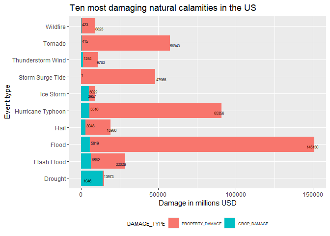

```r
#summarize by total
cumul_propdmg = aggregate(PROPERTY_DAMAGE ~ EVENT_TYPE, data = storm3, function(x) sum(x, na.rm = TRUE))
cumul_cropdmg = aggregate(CROP_DAMAGE ~ EVENT_TYPE, data = storm3, function(x) sum(x, na.rm = TRUE))
cumul_totaldmg = aggregate(TOTAL_DAMAGE ~ EVENT_TYPE, data = storm3, function(x) sum(x, na.rm = TRUE))

cumul_dmg = merge(cumul_propdmg, cumul_cropdmg, by = "EVENT_TYPE")
cumul_dmg = merge(cumul_dmg, cumul_totaldmg, by = "EVENT_TYPE")

cumul_dmg2 = cumul_dmg[order(cumul_dmg$TOTAL_DAMAGE, decreasing = TRUE)[1:10],1:3] #top ten only

library(tidyr)
cumul_dmg2 = gather(cumul_dmg2, DAMAGE_TYPE, DAMAGE, PROPERTY_DAMAGE:CROP_DAMAGE, factor_key=TRUE)

#plot for comparison
library(ggplot2)
p1 = ggplot(data = cumul_dmg2, aes(x = EVENT_TYPE, y = DAMAGE/1000000, fill = DAMAGE_TYPE)) +
    geom_bar(stat = 'identity') + coord_flip()
p1 = p1 + labs(title = "Ten most damaging natural calamities in the US",
    y = "Damage in millions USD", x = "Event type")
p1 = p1 + geom_text(aes(label=round(DAMAGE/1000000)), size=2,
                    position = position_dodge(width = 0.5), hjust = -0.1)
p1 = p1 + theme(legend.position = "bottom", legend.title = element_text(size = 8),
                legend.text = element_text(size = 6))

p1
```

We see that **floods negatively caused the greatest economic consequence overall at about 145 billion USD**. This is followed by Hurricane or typhoon (~ 85 billion USD), tornado (almost 57 billion USD), storm suge tides (almost 48 billion USD) and flash floods (~22 billion USD). In terms of crop damage, drought contributed the most at almost 14 billion USD followed by flash floods (more than 6 billion USD) and floods (~ 5.8 billion USD).

Next, we look at injuries and fatalities.

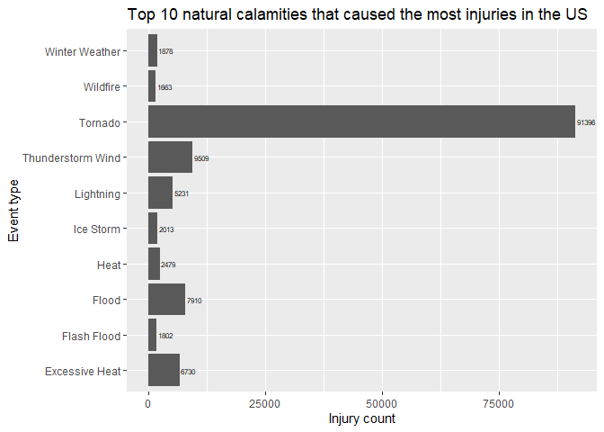

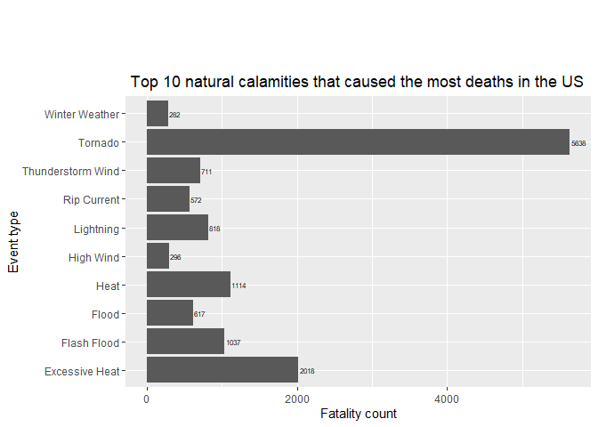

```r
#summarize by total
cumul_injury = aggregate(INJURIES ~ EVENT_TYPE, data = storm3, function(x) sum(x, na.rm = TRUE))
cumul_fatality = aggregate(FATALITIES ~ EVENT_TYPE, data = storm3, function(x) sum(x, na.rm = TRUE))

cumul_injury2 = cumul_injury[order(cumul_injury$INJURIES, decreasing = TRUE)[1:10],] #top ten only
cumul_fatality2 = cumul_fatality[order(cumul_fatality$FATALITIES, decreasing = TRUE)[1:10],] #top ten only


#plots for comparison
p2 = ggplot(data = cumul_injury2, aes(x = EVENT_TYPE, y = INJURIES)) +
    geom_bar(stat = 'identity') + coord_flip()
p2 = p2 + labs(title = "Top 10 natural calamities that caused the most injuries in the US",
    y = "Injury count", x = "Event type")
p2 = p2 + geom_text(aes(label=INJURIES), size=2,
                    position = position_dodge(width = 0.5), hjust = -0.1)
p2


p3 = ggplot(data = cumul_fatality2, aes(x = EVENT_TYPE, y = FATALITIES)) +
    geom_bar(stat = 'identity') + coord_flip()
p3 = p3 + labs(title = "\n\n\n\n Top 10 natural calamities that caused the most deaths in the US",
    y = "Fatality count", x = "Event type")
p3 = p3 + geom_text(aes(label=FATALITIES), size=2,
                    position = position_dodge(width = 0.5), hjust = -0.1)
p3
```

**In general, tornado is the most harmful storm event to the US population’s health**. It recorded more than 91 thousand injuries since 1950 up to 2011. This is followed by thunderstorm winds (9509), floods (7910), excessive heat (6730) and lightning (5231). Similarly tornadoes killed a lot of people, that is, 5638. This is followed by heat waves (3132 total for heat and excessive heat), flash floods (1037) and lightning (818).

In summary, floods, hurricanes or typhoons and tornadoes are the most damaging storm events in terms of econmomic consequence. On the other hand, tornadoes, heat waves and floods (both floods and flashfloods) are the most harmul storm events for the US population’s health. Floods and tornadoes therefore, pose the most threat to the US and risk management of these events should be prioritize, among others.